```python
from IPython.display import HTML
HTML('''<script>
code_show=true;
function code_toggle() {
 if (code_show){
 $('div.input').hide();
 } else {
 $('div.input').show();
 }
 code_show = !code_show
}
$( document ).ready(code_toggle);
</script>
The raw code for this IPython notebook is by default hidden for easier reading.
To toggle on/off the raw code, click <a href="javascript:code_toggle()">here</a>.''')
```

The raw code for this IPython notebook is by default hidden for easier reading. To toggle on/off the raw code, click here.

# RRBS vs. 850k data

- see also http://mhanna.web.elte.hu/rrbs/MarkerRegions.html and http://mhanna.web.elte.hu/rrbs/checkPromoters.html for RRBS results
- 850k top differentially methylated probes and marker gene regions: https://icsabai.github.io/hidden/methyl850k.html , data tables: https://kooplex-fiek.elte.hu/seafile/f/d36357398bd74667a935/

## Conclusion

- only very low portion of 850k probes are present in the RRBS data, typically 3000-13000 probes in samples
- there are only 461 bead array positions, that are present in all 10 RRBS samples
- the correlation between bead array beta and RRBS methylation ratio values is around 0.8
- there are many saturated (0 or 1) RRBS values

```python
import numpy as np
import pandas as pd

import matplotlib.pyplot as plt
import time
%matplotlib inline
```

```python
dataRoot850 = '/mnt/net/onco2/data1/bio/MolnarB_EpicArrayData_20191117/009_0057/raw_data/'
#!ls $dataRoot850
```

```python
dataRootRRBS = '/mnt/net/onco2/data1/bio/onco/RRBSdata_20190828_originalFiles/methylationExtractor_hg19/'
```

### 1. 850k data

- copied from methyl850k.ipynb

Sample from 3_RawData.txt

```python
#meth850 = pd.read_csv(dataRoot850+'3_RawData.txt',skiprows=8,sep='\t', decimal=',',low_memory=False)
#meth850.head(3)
```

|  | TargetID | ProbeID_A | ProbeID_B | 203755070028_R01C01.AVG_Beta | 203755070028_R01C01.Avg_NBEADS_A | 203755070028_R01C01.Avg_NBEADS_B | 203755070028_R01C01.BEAD_STDERR_A | 203755070028_R01C01.BEAD_STDERR_B | 203755070028_R01C01.Signal_A | 203755070028_R01C01.Signal_B | ... | METHYL27_LOCI | METHYL450_LOCI | CHROMOSOME_36 | COORDINATE_36 | SNP_ID | SNP_DISTANCE | SNP_MINORALLELEFREQUENCY | RANDOM_LOCI | Index | Unnamed: 267 |
| --- | --- | --- | --- | --- | --- | --- | --- | --- | --- | --- | --- | --- | --- | --- | --- | --- | --- | --- | --- | --- | --- |
| 0 | cg00000029 | 40668283 | 40668283 | 0.29940 | 10 | 10 | 151 | 42 | 1423 | 651 | ... | NaN | True | 16 | 52025613 | NaN | NaN | NaN | NaN | 1 | NaN |
| 1 | cg00000103 | 76703527 | 76703527 | 0.60186 | 13 | 13 | 61 | 66 | 710 | 1224 | ... | NaN | NaN | 4 | 73689050 | rs16848262;rs146966574;rs61513989 | 1;23;27 | 0.024960;0.000200;0.069090 | NaN | 2 | NaN |
| 2 | cg00000109 | 39798525 | 39798525 | 0.80000 | 12 | 12 | 82 | 134 | 389 | 1958 | ... | NaN | True | 3 | 173398731 | rs572345338;rs9864492;rs553441475;rs183505630 | 2;17;23;24 | 0.000200;0.009784;0.000599;0.003594 | NaN | 3 | NaN |

3 rows × 268 columns

Sample from 2_VariableAnnotation.txt

```python
probeAnnot = pd.read_csv(dataRoot850+'2_VariableAnnotation.txt',skiprows=7,sep='\t',decimal=',',low_memory=False)
probeAnnot.head(3)
```

|  | IlmnID | Name | AddressA_ID | AlleleA_ProbeSeq | AddressB_ID | AlleleB_ProbeSeq | Infinium_Design_Type | Next_Base | Color_Channel | Forward_Sequence | ... | TFBS_NAME | TFBS_Evidence_Count | Methyl27_Loci | Methyl450_Loci | Chromosome_36 | Coordinate_36 | SNP_ID | SNP_DISTANCE | SNP_MinorAlleleFrequency | Random_Loci |
| --- | --- | --- | --- | --- | --- | --- | --- | --- | --- | --- | --- | --- | --- | --- | --- | --- | --- | --- | --- | --- | --- |
| 0 | cg07881041 | cg07881041 | 85713262 | CTACAAATACAACACCCTCAACCCATATTTCATATATTATCTCATT... | NaN | NaN | II | NaN | NaN | CTGCACGCCTACTGCAGGTGCAGCACCCTCAGCCCATGTTTCATGT... | ... | NaN | NaN | NaN | True | 19 | 5187016.0 | rs187313142 | 18 | 0.0002 | NaN |
| 1 | cg18478105 | cg18478105 | 46761277 | AAATAAATTTCACTCTCAAATCCCAATCTCATACAACAAAACAAAA... | 86644198 | AAATAAATTTCGCTCTCAAATCCCAATCTCGTACGACGAAACGAAA... | I | C | Grn | TCCCGTCTTACGGGATGGATTTCGCTCTCAGGTCCCAGTCTCGTGC... | ... | NaN | NaN | NaN | True | 20 | 61318095.0 | rs549944121 | 5 | 0.001797 | NaN |
| 2 | cg23229610 | cg23229610 | 21717843 | ATAAAATTCTTTCCTTAAAAAACATTAAAACCAAAATAAACAAAAA... | NaN | NaN | II | NaN | NaN | GTTTCTGGACAGTAAAATTCTTTCCTTGAAGGACATTAGGGCCAAA... | ... | NaN | NaN | NaN | True | 1 | 6763712.0 | rs545824288;rs527255711 | 40;12 | 0.000200;0.001198 | NaN |

3 rows × 46 columns

Sample from 1_SampleAnnotation.txt

```python
sampleAnnot = pd.read_csv(dataRoot850+'1_SampleAnnotation.txt',sep='\t')
sampleAnnot.head(3)
```

|  | ChipID | SampleID |
| --- | --- | --- |
| 0 | 203786210105_R01C01 | EPIC1 |
| 1 | 203786210105_R02C01 | EPIC2 |
| 2 | 203786210105_R03C01 | EPIC3 |

Cross ID, DIAGENODEmetaadatokRRBSjelolve20191118.xlsx

```python
sampleCrossId = pd.read_excel('../metadata/DIAGENODEmetaadatokRRBSjelolve20191118.xlsx')
sampleCrossId
```

|  | DIAGENODE ID | RRBS ID | Sample ID |
| --- | --- | --- | --- |
| 0 | EPIC1 | 11.0 | 5652NAT |
| 1 | EPIC2 | 12.0 | 5653AD |
| 2 | EPIC3 | 13.0 | 5683NAT |
| 3 | EPIC4 | 14.0 | 5684AD |
| 4 | EPIC5 | 7.0 | 5646NAT |
| 5 | EPIC6 | 8.0 | 5648CRC |
| 6 | EPIC7 | 9.0 | 5662CRC |
| 7 | EPIC8 | 10.0 | 5663NAT |
| 8 | EPIC9 | 17.0 | 5690NAT |
| 9 | EPIC10 | 18.0 | 5689CRC |
| 10 | EPIC11 | NaN | Tr1NAT |
| 11 | EPIC12 | NaN | Tr1CRC |
| 12 | EPIC13 | NaN | Tr2NAT |
| 13 | EPIC14 | NaN | Tr2CRC |
| 14 | EPIC15 | NaN | Tr3NAT |
| 15 | EPIC16 | NaN | Tr3CRC |
| 16 | EPIC17 | NaN | Tr4NAT |
| 17 | EPIC18 | NaN | Tr4CRC |
| 18 | EPIC19 | NaN | Tr5NAT |
| 19 | EPIC20 | NaN | Tr5CRC |
| 20 | EPIC21 | NaN | Tr6NAT |
| 21 | EPIC22 | NaN | Tr6CRC |
| 22 | EPIC23 | NaN | Tr7NAT |
| 23 | EPIC24 | NaN | TrCRC7 |

```python
print('These are the pairs for samples where we have both RRBS and 850k:')
nat = []
adcrc = []
natSample = []
adcrcSample = []

for i in range(5):   # there are 12 pairs total, but here we use only the old samples with RRBS
    e1 = sampleCrossId['DIAGENODE ID'].values[2*i]
    e2 = sampleCrossId['DIAGENODE ID'].values[2*i+1]
    b1 = sampleAnnot[sampleAnnot['SampleID']==e1]['ChipID'].values[0]
    b2 = sampleAnnot[sampleAnnot['SampleID']==e2]['ChipID'].values[0]
    if i==3: # for some resaon here they are in the other orders
        nat.append(b2)
        adcrc.append(b1)
        natSample.append(sampleCrossId['Sample ID'].values[2*i+1])
        adcrcSample.append(sampleCrossId['Sample ID'].values[2*i])
        print(sampleCrossId['Sample ID'].values[2*i+1],sampleCrossId['Sample ID'].values[2*i],
         e2,e1,b2,b1)
    else:
        nat.append(b1)
        adcrc.append(b2)
        natSample.append(sampleCrossId['Sample ID'].values[2*i])
        adcrcSample.append(sampleCrossId['Sample ID'].values[2*i+1])
        print(sampleCrossId['Sample ID'].values[2*i],sampleCrossId['Sample ID'].values[2*i+1],
         e1,e2,b1,b2)
```

```
These are the pairs for samples where we have both RRBS and 850k:
5652NAT 5653AD EPIC1 EPIC2 203786210105_R01C01 203786210105_R02C01
5683NAT 5684AD EPIC3 EPIC4 203786210105_R03C01 203786210105_R04C01
5646NAT 5648CRC EPIC5 EPIC6 203786210105_R05C01 203786210105_R06C01
5663NAT 5662CRC EPIC8 EPIC7 203786210105_R08C01 203786210105_R07C01
5690NAT 5689CRC EPIC9 EPIC10 203755070028_R01C01 203755070028_R02C01
```

```python
adcrcCol = []
natCol = []
for x1 in adcrc:
    adcrcCol.append(x1+'.AVG_Beta')
for x1 in nat:
    natCol.append(x1+'.AVG_Beta')
```

```python
#natBeta = meth850[natCol].values
#adcrcBeta = meth850[adcrcCol].values
```

```python
#df1 = pd.DataFrame(np.column_stack([meth850[['TargetID']].values,natBeta,adcrcBeta]),columns=np.column_stack([['TargetID'],[natSample],[adcrcSample]])[0])
```

Sample bead array beta values:

```python
#df1.head()
```

|  | TargetID | 5652NAT | 5683NAT | 5646NAT | 5663NAT | 5690NAT | 5653AD | 5684AD | 5648CRC | 5662CRC | 5689CRC |
| --- | --- | --- | --- | --- | --- | --- | --- | --- | --- | --- | --- |
| 0 | cg00000029 | 0.32018 | 0.34365 | 0.42469 | 0.25157 | 0.2994 | 0.13846 | 0.21775 | 0.22362 | 0.30478 | 0.2492 |
| 1 | cg00000103 | 0.63402 | 0.63554 | 0.78835 | 0.60452 | 0.60186 | 0.60293 | 0.41134 | 0.69829 | 0.71621 | 0.63168 |
| 2 | cg00000109 | 0.82215 | 0.80139 | 0.81619 | 0.70189 | 0.8 | 0.90963 | 0.82576 | 0.92503 | 0.87678 | 0.81762 |
| 3 | cg00000155 | 0.91708 | 0.89503 | 0.90788 | 0.92907 | 0.89626 | 0.90463 | 0.90107 | 0.92472 | 0.91871 | 0.91845 |
| 4 | cg00000158 | 0.86325 | 0.81731 | 0.88578 | 0.90546 | 0.86676 | 0.8799 | 0.87202 | 0.85154 | 0.90354 | 0.84696 |

After joining with annotation with chromosome and position info:

```python
#df2 = pd.merge(probeAnnot[['IlmnID',  'CHR', 'MAPINFO']][~np.isnan(probeAnnot['MAPINFO'].values)],df1,left_on='IlmnID',right_on='TargetID' )
#df2[['MAPINFO']] = df2[['MAPINFO']].astype('int32')
#df2.head()
```

|  | IlmnID | CHR | MAPINFO | TargetID | 5652NAT | 5683NAT | 5646NAT | 5663NAT | 5690NAT | 5653AD | 5684AD | 5648CRC | 5662CRC | 5689CRC |
| --- | --- | --- | --- | --- | --- | --- | --- | --- | --- | --- | --- | --- | --- | --- |
| 0 | cg07881041 | 19 | 5236016 | cg07881041 | 0.87554 | 0.88043 | 0.86672 | 0.91963 | 0.86992 | 0.8634 | 0.87889 | 0.85481 | 0.91134 | 0.88893 |
| 1 | cg18478105 | 20 | 61847650 | cg18478105 | 0.01499 | 0.01966 | 0.01884 | 0.00926 | 0.01619 | 0.01911 | 0.02237 | 0.00817 | 0.01032 | 0.0131 |
| 2 | cg23229610 | 1 | 6841125 | cg23229610 | 0.82805 | 0.80554 | 0.79835 | 0.86258 | 0.83144 | 0.81624 | 0.82466 | 0.83174 | 0.89674 | 0.81804 |
| 3 | cg03513874 | 2 | 198303466 | cg03513874 | 0.84632 | 0.83033 | 0.87136 | 0.93222 | 0.81531 | 0.74397 | 0.62766 | 0.88511 | 0.88364 | 0.8851 |
| 4 | cg09835024 | X | 24072640 | cg09835024 | 0.02937 | 0.05362 | 0.02781 | 0.03231 | 0.01946 | 0.02126 | 0.29327 | 0.02888 | 0.02427 | 0.02872 |

```python
#df2.to_pickle('/mnt/net/onco2/data0/users/csabai/soteMethyl/saveBeta1.pkl')
df2 = pd.read_pickle('/mnt/net/onco2/data0/users/csabai/soteMethyl/saveBeta1.pkl')
```

```python
## to free up memory
#del df1
#del meth850
```

#### Handle NaN-s

- Some 850k probes (? calibration probes) are in the annotation table but not measured by the chip, so have empty cells in the data table. We drop these.

```python
## some calibration probes may have NaN values
print('Size before:',df2.shape)
df2.dropna(inplace=True)
print('Size after dropping NaN values:',df2.shape)
```

```
Size before: (866091, 14)
Size after dropping NaN values: (844624, 14)
```

#### Convert data types

- Because of NaN values, beta data was defined as "object" type, now convert to "float" numbers.

```python
#df2.dtypes
```

```python
cols = df2.columns.drop(['IlmnID','CHR','MAPINFO','TargetID'])
df2[cols] = df2[cols].apply(pd.to_numeric)
```

```python
#df2.dtypes
```

### 2. The files with RRBS coverages

```python
#!ls -ltr /mnt/net/onco2/data1/bio/onco/*RRBS*
```

```python
#!ls $dataRootRRBS*.cov
```

Sample RRBS coverage data (after alignment and Bismark peak calling):

```python
! head -5 $dataRootRRBS/5646NAT_trimmed_bismark_bt2.bismark.cov
```

```
5	12155	12155	76.9230769230769	40	12
5	12177	12177	59.6153846153846	31	21
5	12182	12182	88.4615384615385	46	6
5	12188	12188	88.4615384615385	46	6
5	12203	12203	100	52	0
```

Columns are:

```
chrom, posStart, posEnd, methRatio100, methCnt, unMethCnt
```

The starting and ending positions are seems to be the same. A typical file contains around 5M positions.

### 3. Join RRBS and 850k

```python
allMerge = []
for x in np.concatenate([natSample,adcrcSample]):
    fnam = dataRootRRBS + x + '_trimmed_bismark_bt2.bismark.cov'
    print(fnam)
    rrbs = pd.read_csv(fnam,sep='\t',header=None, names=['chrom', 'posStart', 'posEnd', 'methRatio100', 'methCnt', 'unMethCnt'])
    merge1 = pd.merge(df2[['IlmnID',  'CHR', 'MAPINFO',x]],rrbs,left_on=['CHR', 'MAPINFO'],right_on=['chrom','posStart'])
    allMerge.append([x,merge1.copy()])
```

```
/mnt/net/onco2/data1/bio/onco/RRBSdata_20190828_originalFiles/methylationExtractor_hg19/5652NAT_trimmed_bismark_bt2.bismark.cov
```

```
/mnt/net/onco2/data1/bio/onco/RRBSdata_20190828_originalFiles/methylationExtractor_hg19/5683NAT_trimmed_bismark_bt2.bismark.cov
/mnt/net/onco2/data1/bio/onco/RRBSdata_20190828_originalFiles/methylationExtractor_hg19/5646NAT_trimmed_bismark_bt2.bismark.cov
/mnt/net/onco2/data1/bio/onco/RRBSdata_20190828_originalFiles/methylationExtractor_hg19/5663NAT_trimmed_bismark_bt2.bismark.cov
/mnt/net/onco2/data1/bio/onco/RRBSdata_20190828_originalFiles/methylationExtractor_hg19/5690NAT_trimmed_bismark_bt2.bismark.cov
/mnt/net/onco2/data1/bio/onco/RRBSdata_20190828_originalFiles/methylationExtractor_hg19/5653AD_trimmed_bismark_bt2.bismark.cov
/mnt/net/onco2/data1/bio/onco/RRBSdata_20190828_originalFiles/methylationExtractor_hg19/5684AD_trimmed_bismark_bt2.bismark.cov
/mnt/net/onco2/data1/bio/onco/RRBSdata_20190828_originalFiles/methylationExtractor_hg19/5648CRC_trimmed_bismark_bt2.bismark.cov
/mnt/net/onco2/data1/bio/onco/RRBSdata_20190828_originalFiles/methylationExtractor_hg19/5662CRC_trimmed_bismark_bt2.bismark.cov
/mnt/net/onco2/data1/bio/onco/RRBSdata_20190828_originalFiles/methylationExtractor_hg19/5689CRC_trimmed_bismark_bt2.bismark.cov
```

### 4. Calculate correlations and plot

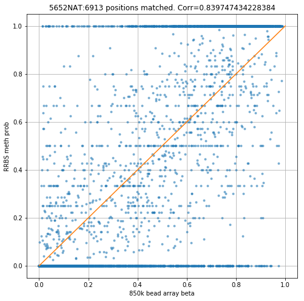

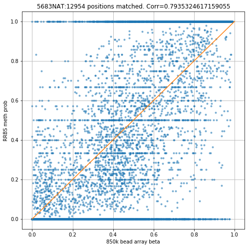

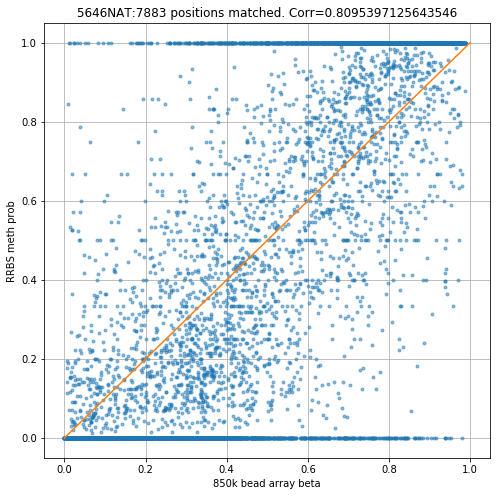

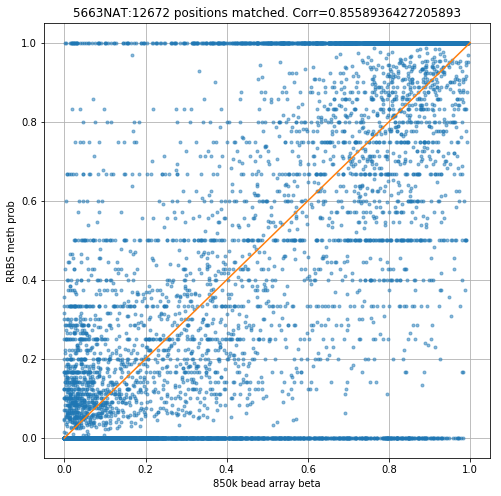

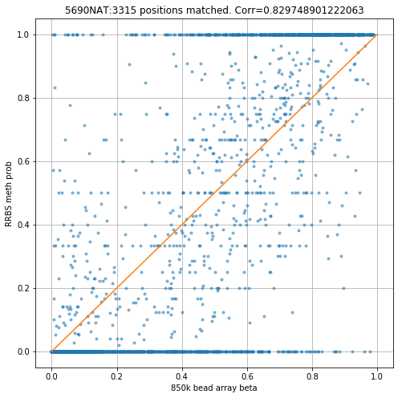

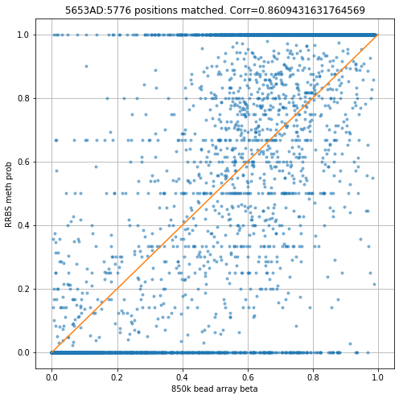

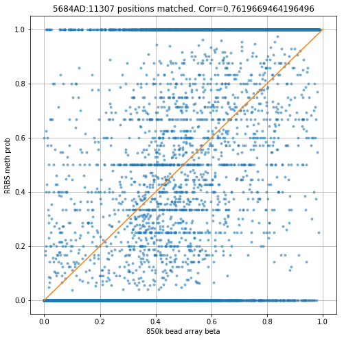

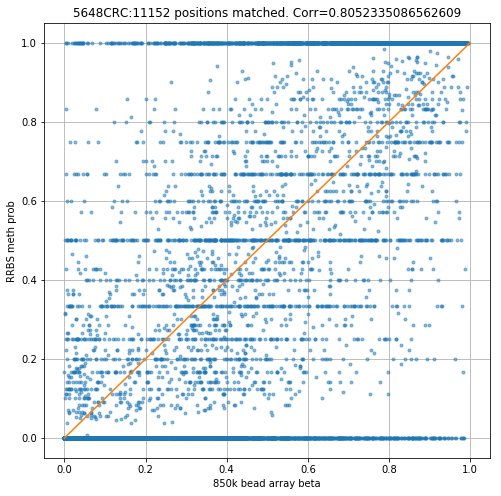

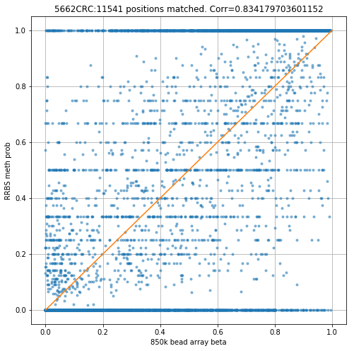

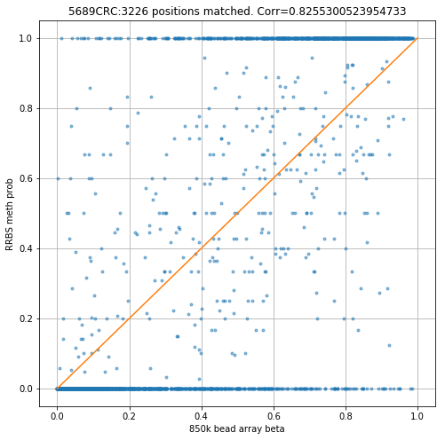

```python
for i,x in enumerate(np.concatenate([natSample,adcrcSample])):
    hits = allMerge[i][1].shape[0]
    corr = np.corrcoef(allMerge[i][1][x].values.astype(float),y=allMerge[i][1]['methRatio100'].values/100)[0,1]
    plt.figure(figsize=[8,8])
    plt.plot(allMerge[i][1][x].values,allMerge[i][1]['methRatio100'].values/100,'.', alpha=0.5)
    plt.plot([0,1],[0,1],'-')
    plt.title(x + ':' + str(hits) + ' positions matched. Corr='+str(corr) )
    plt.xlabel('850k bead array beta')
    plt.ylabel('RRBS meth prob')
    plt.grid()
    plt.show()
```

### 5. The common bead array probe positions in all samples

```python
for i,x in enumerate(np.concatenate([natSample,adcrcSample])):
    if i == 0:
        m1 = allMerge[i][1]
    else:
        m1 = pd.merge(m1,allMerge[i][1],left_on=['CHR','MAPINFO'],right_on=['CHR','MAPINFO'])
    allMerge[i][1].to_excel('/mnt/net/onco2/data0/users/csabai/soteMethyl/'+x+'RRBS_850k_join.xlsx')
```

```python
print('The number of common 850k positions in all ',len(np.concatenate([natSample,adcrcSample])),' RRBS samples is: ',m1.shape[0])
```

```
The number of common 850k positions in all  10  RRBS samples is:  461
```